# Preparação de Dados da População

- Mostrar o código
- Esconder o código
- Ver o código fonte

Censo Demográfico 2022

Autor

Gustavo Givisiez

Data de Publicação

11 de junho de 2026

**Código**

```r
library(dplyr)
library(sf)
library(tmap)
library(geomarkbr)
tmap::tmap_mode("plot")
```

# 1 Censo Demográfico

**Nota🤓 Código de desenvolvimento (dev)**

**Código**

```r
# dev shape
setores_rj <- gm_read_sectors_data(code = 33)|>
  dplyr::mutate(code_tract = as.character(code_tract))
#dados_pf = "site/tutorials/dados/" #dev
readr::write_sf(setores_rj,paste0(dados_pf,"shape_rj.gpkg") overwrite = TRUE)
```

**Código**

```r
# dev data
dados_basico_rj <- gm_read_sectors_data(code = 33)
dados_pessoas_rj <- gm_read_sectors_data(code = 33,
                                dataset = "Pessoas")
dados_responsavelrenda_rj <- gm_read_sectors_data(code = 33,
                                dataset = "ResponsavelRenda")

readr::write_rds(dados_basico_rj,"site/tutorials/dados/data_basico_rj.rds")
readr::write_rds(dados_pessoas_rj,"site/tutorials/dados/data_pessoas_rj.rds")
readr::write_rds(dados_responsavelrenda_rj,"site/tutorials/dados/data_responsavelrenda_rj.rds")
```

## 1.1 Baixar dados do Censo

Para baixar as shapes dos setores censitários o comando `gm_read_sectors_shape` busca as shapes no servidor do IPEA. Na sequencia baixamos os dados de São José de Ubá (RJ).

**Código**

```r
gm_read_sectors_shape(code = 3305133) # São José de Ubá (RJ)
```

Entretanto, o download direto dos setores censitários via internet pode apresentar instabilidade, seja por limitações de conexão ou mudanças nos servidores. Para garantir que todos consigam acompanhar a aula sem problemas, utilizaremos uma base local para o Rio de Janeiro previamente baixada pelo pacote `geobr`.

A partir dessa base, iremos **filtrar apenas o município de São João da Barra (código 3305000)**, trabalhando com um conjunto de dados menor e mais adequado para as atividades em sala.

**Código**

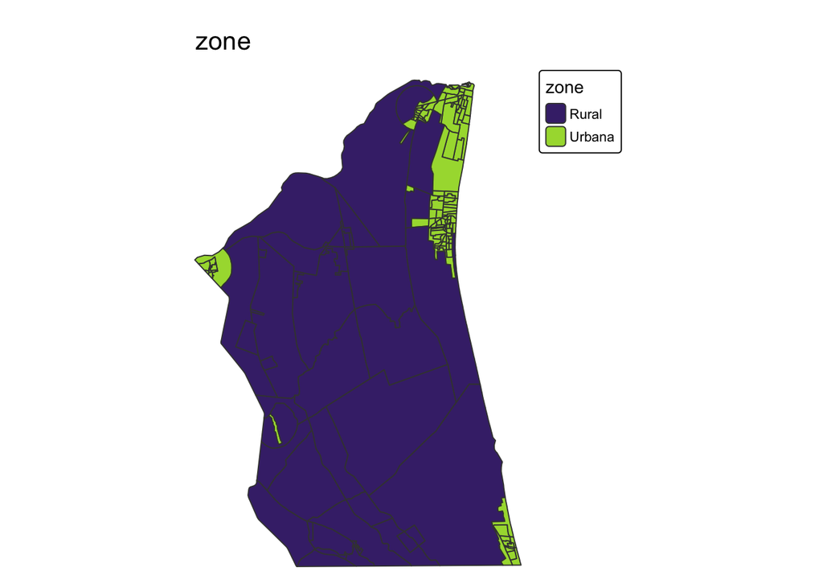

```r
# Base local (RJ inteiro) + filtro para São João da Barra

dados_pf = here::here('tutorials/dados/') # substitua pelo caminho da aula_geomarketing
                                          # Acho que '~/aula_geomarketing/data' funciona
setores <- gm_read_sectors_shape(
  path = paste0(dados_pf,"shape_rj.gpkg"),
  code = 3305000
)

gm_plot_basic(setores, var = 'zone')
```

**Dica💡 Dica**

Os setores censitários podem ser obtidos diretamente por meio de uma ampla gama de codigos. O argumento `code` da função `gm_read_sectors` segue lógica similar ao pacote `geobr` com algumas variações:

- Se for informado um código de município com 7 dígitos (por exemplo, `3305000`), a função retorna apenas os setores desse município.
- Se for informado um código de estado (por exemplo, `33`) ou a sigla da unidade da federação (por exemplo, `"RJ"`), a função retorna todos os setores daquele estado.
- Se for informado `"all"`, a função retorna os setores de todo o Brasil.
- Há outras formas de baixar dados dos Setores Censitários previstos nessa função (bairro, cidade, regiões intermediárias, etc.). Consulte `?gm_read_sectors` para mais informações

Essa flexibilidade permite trabalhar com diferentes escalas territoriais, desde um único município até o país inteiro.

Para baixar os dados propriamente dito, a função é `gm_read_sectors_data`, como a seguir. No default, a fução baixa o `dataset='Basico'`

Mas, como antes, nem sempre os dados estão disponíveis e por isso vamos usar a base com dados locais para o Rio de Janeiro. Selecionamos apenas o município de São João da Barra

**Código**

```r
# Base local (RJ inteiro) + filtro para São João da Barra
dados_basico <- gm_read_sectors_data(
  path = paste0(dados_pf,"data_basico_rj.rds"),
  code = 3305000
)
```

Lembrem-se que para juntar dados com setores é pelo `gm_join_data`

**Código**

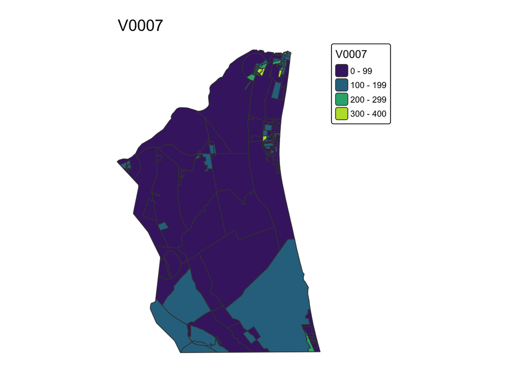

```r
base <- gm_join_data(dados_basico, setores)

gm_plot_basic(base, var = 'V0007')
```

## 1.2 Entendendo o dicionário do censo

Há infinitas bases de dados no Brasil e no munndo. Mas, elas são ilegíveis e inúteis sem o dicionário, que deve sempre (ou quase sempre) acompanhar as bases de dados. Essa seção se dedica a entender o dicionário e, por meio dele, selecionar as variáveis que nos interessam. O dicionário dos setores censitários são disponibilizados pelo `censobr::data_dictionary(year = 2022, dataset = "tracts")` e já estão salvos na estrutura do pacote.

O comando a seguir acha esse dicionário e abre o Excel.

**Código**

```r
file <- gm_example_data_path("2022_dictionary_tracts.xlsx")
utils::browseURL(file)
```

O arquivo Excel do dicionário é organizado em planilhas, cada uma correspondente a um dos conjuntos de dados disponíveis (`dataset`) no `censobr::read_tracts()`, além de planilhas auxiliares com informações complementares. A planilha **Siglas_Basico** apresenta o dicionário das siglas utilizadas nas variáveis V0001 a V0007 do conjunto `dataset = "Basico"`. As demais planilhas correspondem aos principais conjuntos temáticos de variáveis: **Basico**, **Pessoas**, **Domicilios**, **Obitos**, **Indigenas**, **Quilombolas**, **ResponsavelRenda** e **Entorno**. Cada uma dessas planilhas descreve as variáveis disponíveis em seu respectivo dataset, permitindo identificar seus códigos, descrições e formas de uso na análise dos dados censitários.

## 1.3 Processarmento das variáveis de interesse

A partir desse ponto, começa o trabalho “real” de selecionar as variáveis que nos interessam no banco de dados. Nesse exemplo vamos filtar a renda média do chefe no setor censitário e calcular a proporção de crianças dentro do setor.

**Dica💡 Dica**

Lembrem-se que podemos filtrar desde já quais *territórios* vamos trabalhar. No exemplo abaixo filtramos os dados sobre a renda do chefe e dados demográficos para o município de São João da Barra.

**Código**

```r
dados_pessoas <- gm_read_sectors_data(code = 3305000,
                                      path = paste0(dados_pf,"data_pessoas_rj.rds"),
                                      dataset = "Pessoas")

dados_responsavelrenda <- gm_read_sectors_data(code = 3305000,
                                               path = paste0(dados_pf,"data_responsavelrenda_rj.rds"),
                                               dataset = "ResponsavelRenda")
```

## 1.4 Renomear variáveis e limpar o banco

Dois problemas surgem quando estamos trabalhando com grandes bases de dados. Sao muitas variáveis: o banco de dados depessoas tem 724 variáveis e o da renda é até menorzinho com 54 colunas. A primeira tarefa é deixar na base apenas as vaiáveis que nos interessam.

Para a renda dos setores censitários temos duas medidas de tendência central: - **V06004**: Rendimento nominal (em reais em 01/08/2022) médio dos responsáveis com rendimentos (DPP ocupados) - **V06005**: Variância do rendimento mensal dos responsáveis com rendimentos (DPP ocupados)

Para a proporção de crianças: - **demografia_V01006**: Quantidade de moradores - **demografia_V01031**: Quantidade de moradores de 0 a 4 anos - **demografia_V01032**: Quantidade de moradores de 5 a 9 anos - **demografia_V01033**: Quantidade de moradores de 10 a 14 anos

Precisamos ainda deixar nas tabelas de dados a variável `code_tract` que identifica o setor censitário e é a chave de união das tabelas.

A ideia não é decorar todos os comandos, mas entender o fluxo. Assim, os passos quase sempre serão:

1. `Selecionar` colunas e `Filtar` o conjunto de dados
2. `Renomear` colunas
3. `Calcular` indicadores
4. `Unir` as bases processadas com as shapes (se pertinente)
5. `Salvar` a base processada

As três primeiras etapas podem ser encadeadas em uma sequência de pipes (`%>%`), como no codigo a seguir. Após o processamento, é uma boa prática salvar a base já organizada. Isso evita repetir todas as etapas de preparação sempre que o projeto for aberto novamente.

**Código**

```r
dados_responsavelrenda_clean = dados_responsavelrenda %>%
  select(code_tract, V06004, V06005) %>% # selecionar
  rename(renda_media = V06004,
         renda_var = V06005) # renomear

dados_pessoas_clean = dados_pessoas %>%
  select(code_tract, demografia_V01006, demografia_V01031, demografia_V01032, demografia_V01033) %>% # selecionar
  rename(pop = demografia_V01006,
         pop_abs_00_04 = demografia_V01031,
         pop_abs_05_09 = demografia_V01032,
         pop_abs_10_14 = demografia_V01033) %>% # renomear
  mutate(
    pop_criancas =
      coalesce(pop_abs_00_04, 0) +
      coalesce(pop_abs_05_09, 0) +
      coalesce(pop_abs_10_14, 0),
  perc_criancas = pop_criancas/pop) # calcular


dados_all = gm_join_data(dados_responsavelrenda_clean, base) #unir a base com a renda
dados_all = gm_join_data(dados_pessoas_clean, dados_all) # unir a base_all (etapa anterior) com demografia

readr::write_rds(
  dados_all,
  paste0(dados_pf,"dados_all.rds")
) # salvar o arquivo processado
```

**Nota🤓 Para saber mais sobre o pacote `dplyr`**

O pacote `dplyr` é um pacote construído para manipulação de dados e usa tipo de gramática para isso. Essa gramática prevê um conjunto de funções (*verbos*) consistentes para ajudar a resolver os principais desafios da manipulação de base de dados. A sintaxe dessa gramática é `x %>% função` onde o `x` seria o dataframe ou a shape (o *sujeito*) e a `função` é um comando do R. O símbolo `%>%` é, por convenção chamado de pipe (conector, em português) que junta um objeto com a função. Escrever o comando `x %>% comando` é o mesmo que escrever `comando(x)` (execute esse comando em x).

**Código**

```r
x<-c(3,6,9,26)
sum(x)
```

```
#> [1] 44
```

```r
## É o mesmo que
x %>% sum()
```

```
#> [1] 44
```

Alguns dos principais comandos do `dplyr` são:

**`select()`**: Seleciona colunas da base de dados. É útil para reduzir o número de variáveis e manter apenas aquelas necessárias para a análise. `select(code_tract, pop, renda_media)` seleciona as variáveis `code_tract`, `pop` e `renda_media`.

**`filter()`**: Filtra linhas da base de dados a partir de alguma condição lógica. `filter(pop > 1000)` mantém apenas os setores com mais de 1000 moradores.

**`rename()`**: Renomeia variáveis para nomes mais curtos ou mais fáceis de interpretar. `rename(pop_total = V01006)` renomeia variável `V01006` de `pop_total`.

**`mutate()`**: Cria novas variáveis ou altera variáveis existentes. `mutate(densidade = pop / area)` calcula a densidade populacional.

**`coalesce()`**: Substitui valores ausentes (`NA`) por outro valor. `coalesce(pop_abs_00_04, 0)` substitui valores ausentes por zero. O comando `coalesce` é muito útil porque operações matemáticas envolvendo valores `NA` (ou *missing*) normalmente retornam `NA`.

## 1.5 Desenhar a grade e distribuir a população

**Código**

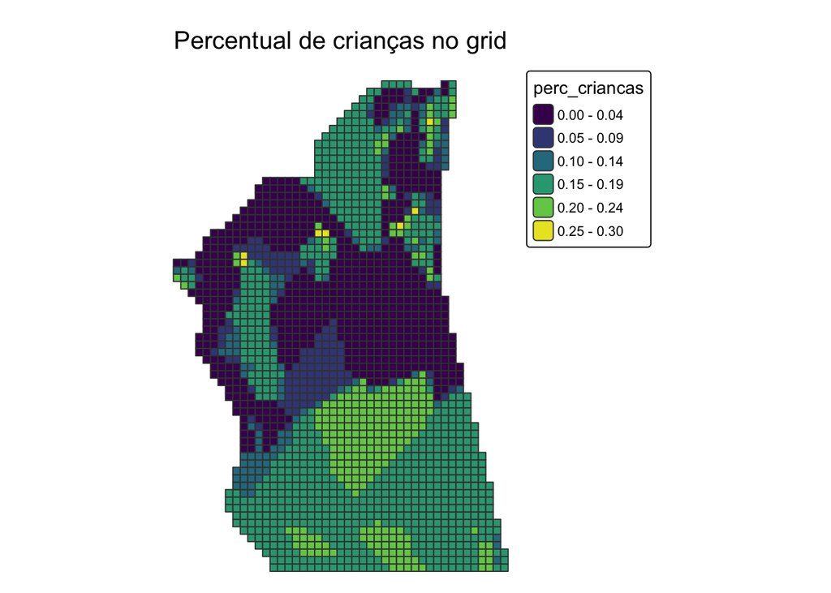

```r
dados_all_utm <- sf::st_transform(dados_all, 31984) # converter para UTM
grid_utm <- gm_make_grid(dados_all_utm, type = "metric", cellsize = 500) # criar a grade

grid_base = gm_interpolation_2_grid(grid_utm, dados_all_utm,
                        vars_extensive = c('pop'),
                        vars_intensive= c('perc_criancas','renda_media')) # interpolação para a grade

grid_base = grid_base %>%
  mutate(dens_pop = pop / (0.5*0.5)) # calculcar a densidade populacional na grade

gm_plot_basic(grid_base, var = 'perc_criancas', titulo = 'Percentual de crianças no grid')
```

**Código**

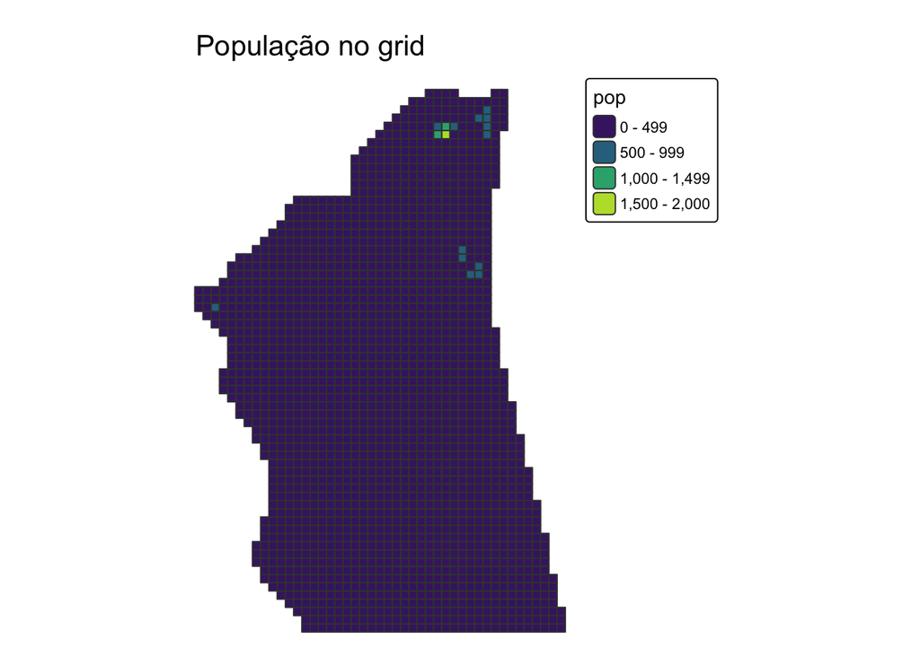

```r
gm_plot_basic(grid_base, var = 'pop', titulo = 'População no grid')
```

**Código**

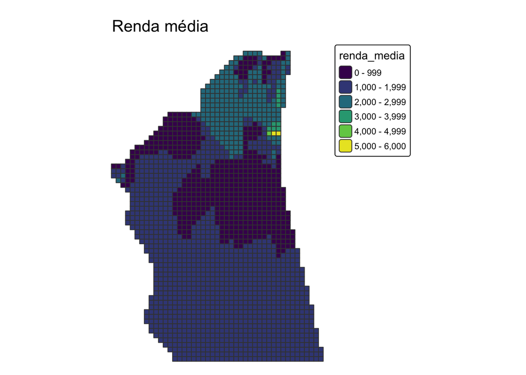

```r
gm_plot_basic(grid_base, var = 'renda_media', titulo = 'Renda média')
```

**Código**

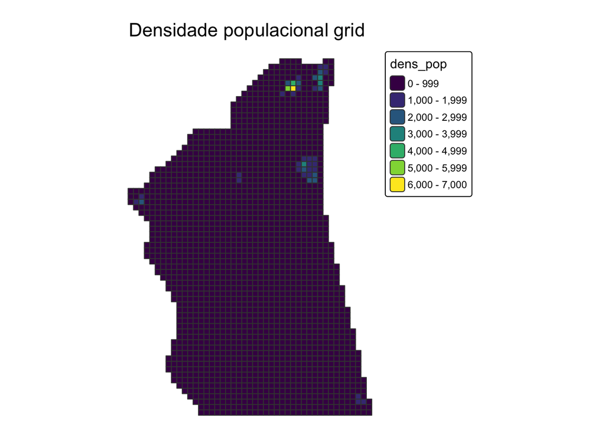

```r
gm_plot_basic(grid_base, var = 'dens_pop', titulo = 'Densidade populacional grid')
```

Você podem salvar essa base processada (`grid_base`) como o formato nativo do R (`*.rds`) ou como Geopackage (`*.gpkg` que pode ser aberto no QGIS)

**Código**

```r
readr::write_rds(
    grid_base,
    paste0(dados_pf,"grid_base.rds")
) # salvar o arquivo processado como rds

sf::write_sf(
    grid_base,
    paste0(dados_pf,"grid_base.gpkg")
) # salvar o arquivo processado como gpkg
```

**Importante📝 Exercício**

O objetivo deste exercício é aplicar o fluxo de preparação de dados desenvolvido nesta aula utilizando outras variáveis dos Agregados por Setor Censitário do Censo Demográfico de 2022.

Escolha um município do estado do Rio de Janeiro (`code_muni` de Campos é `3301009`) e produza uma base processada contendo:

1. A proporção de homens entre 20 e 39 anos;
2. A proporção de alfabetizados no setor censitário.

Para isso, vocês deverão:

1. Consultar o dicionário do Censo e identificar quais variáveis representam:
   - população masculina nas faixas etárias desejadas;
   - população alfabetizada;
   - população total (denominador do indicador).
2. Baixar ou filtrar os dados do município escolhido;
3. Selecionar apenas as variáveis necessárias;
4. Renomear as colunas para nomes mais compreensíveis;
5. Calcular:
   - o total de homens entre 20 e 39 anos;
   - a proporção de alfabetizados no setor;
6. Unir os dados às shapes dos setores censitários;
7. Produzir pelo menos dois mapas temáticos:
   - um para população masculina de 20 a 39 anos;
   - outro para proporção de alfabetizados.

### 1.5.1 🧐 Sugestões

- Municípios menores tendem a processar mais rapidamente;
- Usem nomes curtos e claros para as variáveis;
- Salvem a base processada em formato `.rds`;
- Tentem interpretar espacialmente os padrões encontrados.

### 1.5.2 🤓 Desafio adicional (opcional)

Experimentem: - alterar a paleta de cores; - inserir título e legenda personalizados; - criar uma grade regular e interpolar os indicadores para ela.

**Nota🌎 **Para saber mais** sobre os filtros territoriais avançados**

A menor uniddade territorial são os setores censitários que são identificados por `code_tract`. Dessa forma é possível filtrar na base um único setor ou vários. Usando o `dplyr` essa filtragem pode ser feita da seguinte forma:

**Código**

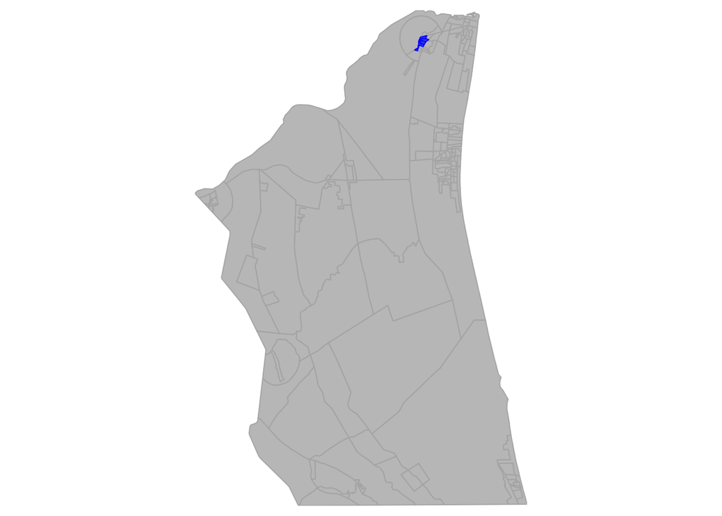

```r
setores_aleatorios = dados_all_utm %>%
  filter(code_tract %in% c('330500005000002','330500005000003', '330500005000004','330500005000005'))
gm_plot_overlay(base = base,
                base_fill = 'grey50',base_alpha = 0.5,
                overlay = setores_aleatorios,
                overlay_fill = 'blue', overlay_col = 'blue'
                )
```

Há outros unidades territoriais intraurbanas nas bases do IBGE que são construídas com agregação de setores censitários:

- `zone` e `code_situacao`: Urbano / Rural
- `code_neighborhood` e `name_neighborhood`: Bairros
- `code_district` e `name_district`: Distritos
- `code_subdistrict` e `name_subdistrict`: Subdistritos
- `code_nucleo_urbano` e `name_nucleo_urbano`: Núcleos urbanos
- `code_favela` e `name_favela`: Favelas
- `code_aglomerado` e `name_aglomerado`: Aglomerados

Há ainda unidades territoriais que se baseiam nos municípios (`code_muni` e `name_muni`) e estados. - `code_state`, `name_state` e `abbrev_state`: Estados - `code_intermediate` e `name_intermediate`: Região intermediária - `code_immediate` e `name_immediate`: Região imediata

Todos esses códigos podem ser usados nos comandos de importação de shapes:

**Código**

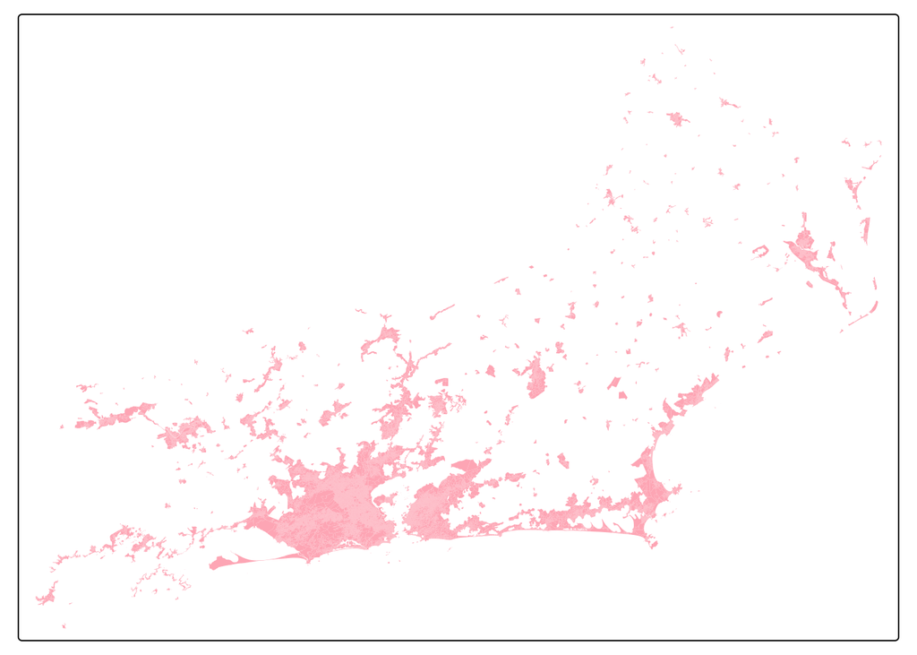

```r
sh = gm_read_sectors_shape(
    path = paste0(dados_pf,"shape_rj.gpkg"),
    filter_var = 'zone',
    code = 'Urbana',
    state = 'RJ')

tm_shape(shp = sh)+
 tm_polygons(fill = 'lightpink',
             col = NULL)
```

**Código**

```r
sh_campos = gm_read_sectors_shape(
    path = paste0(dados_pf,"shape_rj.gpkg"), # sem esse argumento, busca na internet
    filter_var = 'code_muni',
    code = 3301009,
    state = 'RJ')

unique(sh_campos$code_subdistrict)[1:3] #1º ao 3º subdistrito que estão na lista
```

```
#> [1] 33010090506 33010090507 33010090508
```

```r
sh_1st_subd_campos = gm_read_sectors_shape(
    path = paste0(dados_pf,"shape_rj.gpkg"),
    filter_var = 'code_subdistrict',
    code = 33010090506,
    state = 'RJ')

unique(sh_campos$name_neighborhood)[2:4] #2º e 3º bairros que estão nalista
```

```
#> [1] "Jardim Maria de Queiroz" "Parque Tamandaré"
#> [3] "Parque São Caetano"
```

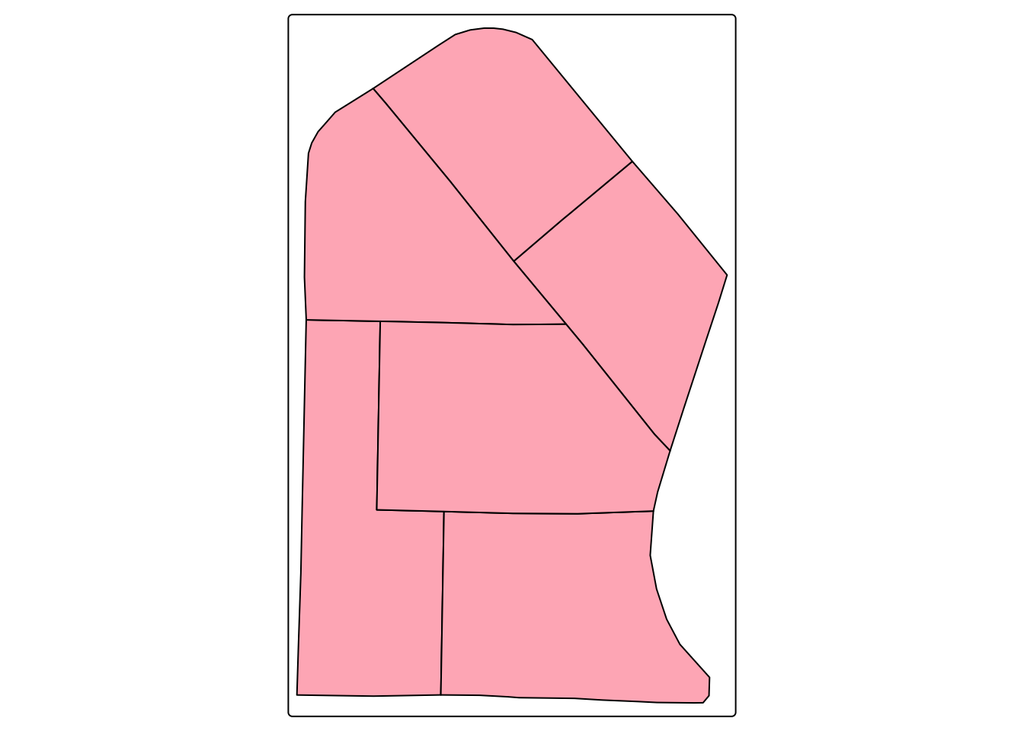

```r
sh_sao_caetano = gm_read_sectors_shape(
    path = paste0(dados_pf,"shape_rj.gpkg"),
    filter_var = 'name_neighborhood',
    code = "Parque São Caetano",
    state = 'RJ')

tm_shape(sh_sao_caetano)+
 tm_polygons(fill = 'lightpink',
             col = 'black')
```

**Código**

```r
tmap::tmap_mode("view")
gm_plot_overlay(base = sh_1st_subd_campos,
                overlay = sh_sao_caetano)
```

[interactive chart not shown]

**Código**

```r
tmap::tmap_mode("plot")
```

**Nota🌎 **Para saber mais** sobre como fazer um mapa com mais e perfumarias**

Até aqui usamos mapas bastante simples, suficientes para visualizar rapidamente uma variável no espaço. No entanto, um mapa também é uma forma de comunicação. Por isso, além de representar os dados, é importante cuidar de alguns elementos cartográficos: escolha da paleta de cores, título, legenda, grade, escala, orientação e fonte dos dados.

**Código**

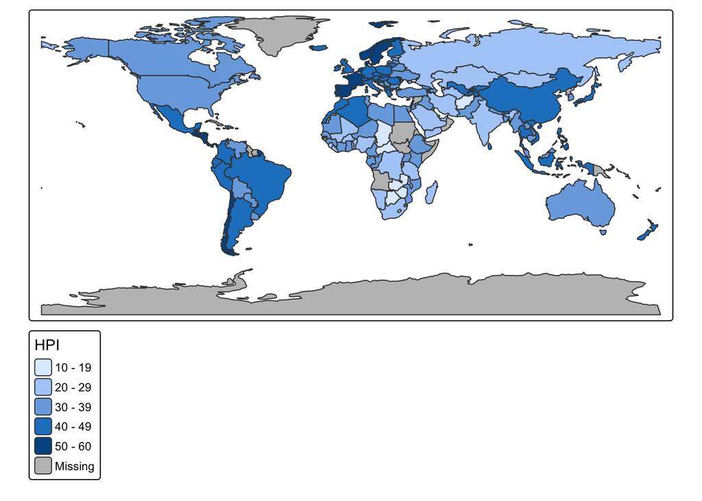

```r
tm_shape(World)+
    tm_polygons(fill = "HPI")
```

**Código**

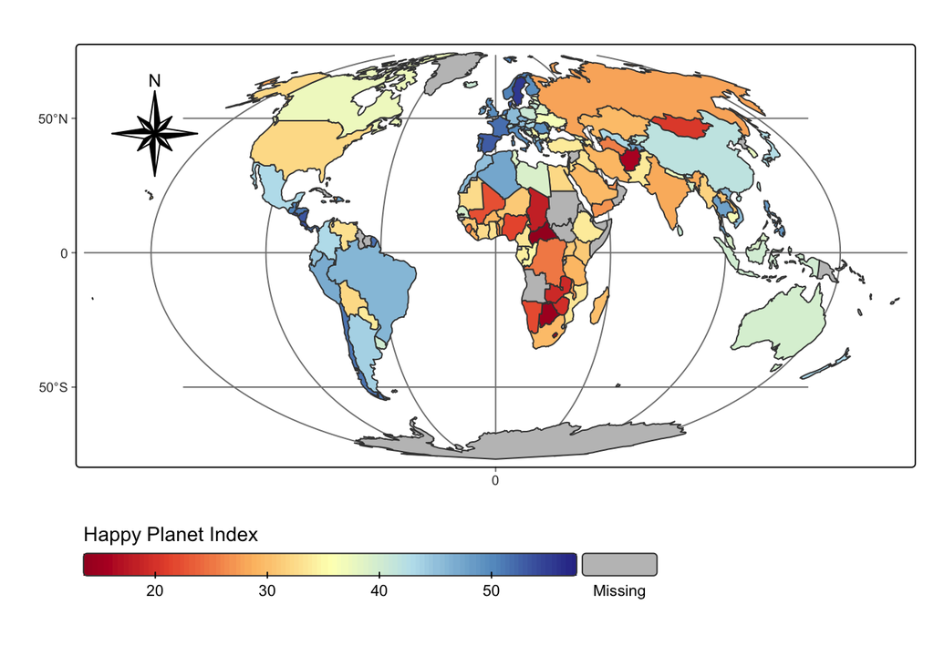

```r
tm_shape(World, crs = "+proj=moll") +
   tm_graticules() +
   tm_compass(type = "8star", position = c("left", "top")) +
    tm_polygons(fill = "HPI",
                fill.scale = tm_scale_continuous(values = "matplotlib.rd_yl_bu"),
                fill.legend = tm_legend(title = "Happy Planet Index",
                                        orientation = "landscape",
                                        frame = FALSE)
                )
```

**Código**

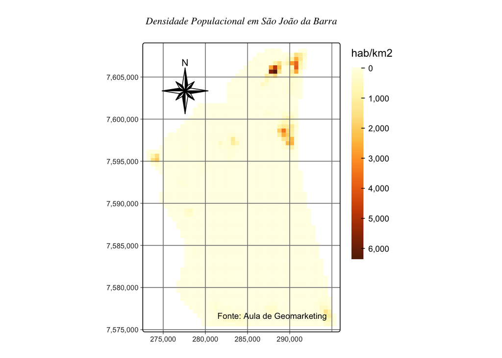

```r
tm_shape(grid_base)+
  tm_polygons(fill = "dens_pop", col = NULL,
              fill.scale = tm_scale_continuous(values = "brewer.yl_or_br"),
              fill.legend = tm_legend(title = "hab/km2",
                                      frame = FALSE))+
  tm_grid() +
  tm_compass(type = "8star", position = c("left", "top")) +
  tm_credits("Fonte: Aula de Geomarketing")+
  tm_title(text = "Densidade Populacional em São João da Barra",
           fontface = "italic",
           fontfamily = "serif")
```

## 2 Referências

GIVISIEZ, G. **Geomarkbr: Ferramentas Para Análise Espacial Aplicada Ao Geomarketing**. Campos dos Goytacazes, RJ: https://github.com/ghnaves/geomarkbr, abr. 2026. Acesso em: 29 abr. 2026.

GONÇALVES, C. N.; PEREIRA, R. H. M.; INSTITUTO DE PESQUISA ECONÔMICA APLICADA (IPEA). **Geobr: Loads Shapefiles of Official Spatial Data Sets of Brazil**. [*S. l.*: *s. n.*], 2009. Acesso em: 4 maio 2026.

LOVELACE, R.; NOWOSAD, J.; MUENCHOW, J. **Geocomputation with R**. Boca Raton, FL: CRC Press, 2019. Acesso em: 6 ago. 2024.

NOWOSAD, M. T. and J. **Elegant and Informative Maps with Tmap**. [*S. l.*: *s. n.*], 2025. Acesso em: 16 maio 2025.

RAFAEL H. M. PEREIRA *et al.* **[Censobr: Download Data from Brazil’s Population Census](https://doi.org/10.32614/CRAN.package.censobr)**. [*S. l.*: *s. n.*], 2023. Acesso em: 4 maio 2026.

WICKHAM, H. *et al.* **[Dplyr: A Grammar of Data Manipulation](https://doi.org/10.32614/CRAN.package.dplyr)**. [*S. l.*]: Comprehensive R Archive Network, jan. 2014. Acesso em: 5 maio 2026.